# Análise dos Visitantes da Praça das Profissões ingressos na UFCG nos períodos 2015.1 a 2017.2

Criado por Hector Medeiros com base nos dados dos visitantes da Praça entre os anos de 2015 a 2017, juntamente com a relação de alunos ingressos na UFCG disponibilizada pela PRE. Todas as consultas envolvidas na pesquisa foram realizadas utilizando banco de dados relacional, sendo o PostGres o Sistema de Gerenciamento de Banco de Dados utilizado.

```python
%matplotlib inline
import pandas as pd
import matplotlib.pyplot as plt
import seaborn as sns
import numpy as np
from IPython.display import display
plt.style.use('ggplot')
```

```python
#Leitura de Arquivo
ingressos = pd.read_csv('resultadosPesquisa.csv')
```

A tabela abaixo engloba os nomes dos alunos juntamente com o curso que eles foram selecionados na UFCG, o curso que eles informaram que teriam interesse em cursar em sua visita na Praça das Profissões e também a escola onde estudavam.

```python
ingressos
```

|  | nome | curso | cursodeinteresse | ingresso | escola |
| --- | --- | --- | --- | --- | --- |
| 0 | ADRIEL MATEUS SILVA XAVIER | ENGENHARIA MECANICA - D (Campina Grande) | NaN | 2017.2 | COLEGIO PANORAMA |
| 1 | ADRIEL MATEUS SILVA XAVIER | METEOROLOGIA - D (Campina Grande) | NaN | 2017.1 | COLEGIO PANORAMA |
| 2 | ALICE MONTEIRO BAZANTE | ENGENHARIA AGRICOLA - D (Campina Grande) | ENGENHARIA CIVIL, ENGENHARIA MECANICA, ARQUITE... | 2017.1 | COLEGIO MOTIVA |
| 3 | ALINE RODRIGUES DA SILVA | ENGENHARIA AMBIENTAL - D (Pombal) | NAO SABE | 2016.1 | ESCOLA ESTADUAL DE ENSINO FUNDAMENTAL E MEDIO ... |
| 4 | AMANDA GUEDES BEZERRA | DESIGN - D (Campina Grande) | ARQUITETURA | 2017.2 | COLEGIO MOTIVA |
| 5 | ANA BEATRIZ DA SILVA GUEDES | LETRAS - LINGUA INGLESA (LIC) - D (Campina Gra... | NAO SABE | 2017.1 | ESCOLA ESTADUAL DE ENSINO FUNDAMENTAL E MEDIO ... |
| 6 | ANA BEATRIZ GOMES BARBOSA | ESTATISTICA - D (Campina Grande) | CIENCIA DA COMPUTACAO\nODONTOLOGIA | 2017.1 | ESCOLA ESTADUAL DE ENSINO FUNDAMENTAL E MEDIO ... |
| 7 | ANDREZA VITORIA SANTOS TAVARES | METEOROLOGIA - D (Campina Grande) | PSICOLOGIA | 2017.1 | ESCOLA ESTADUAL DE ENSINO FUNDAMENTAL E MEDIO ... |
| 8 | ANNE CECILIA GALDINO BARRETO | DIREITO - N (Sousa) | DIREITO | 2017.1 | COLEGIO MOTIVA |
| 9 | ARTHUR COSTA DE FARIAS | ENGENHARIA QUIMICA - D (Campina Grande) | ENGENHARIA | 2017.1 | ESCOLA ESTADUAL DE ENSINO FUNDAMENTAL E MEDIO ... |
| 10 | BRUNA DANTAS DE SOUSA | ENGENHARIA CIVIL - D (Campina Grande) | ARQUITETURA | 2017.1 | COLEGIO MOTIVA |
| 11 | CAMILA EDUARDA TRAVASSOS SILVA | CIENCIAS SOCIAIS (BAC) - D (Campina Grande) | NaN | 2017.1 | ESCOLA ESTADUAL DE ENSINO FUNDAMENTAL E MEDIO ... |
| 12 | CLARICE SOFIA HENRIQUE SOARES | ENGENHARIA ELETRICA (Campina Grande) | ALGUMA ENGENHARIA | 2017.1 | COLEGIO MOTIVA |
| 13 | CRISMARCOS ARAUJO SOUSA | ADMINISTRACAO - D (Campina Grande) | BIOMEDICINA | 2017.2 | ESCOLA ESTADUAL DE ENSINO FUNDAMENTAL E MEDIO ... |
| 14 | DANILO CESAR ALVES DE SOUZA | ENGENHARIA CIVIL - D (Campina Grande) | NaN | 2017.1 | COLEGIO PANORAMA |
| 15 | DIOGO JOSE GOMES SILVA | MATEMATICA (BAC) - D (Campina Grande) | DIREITO, ENGENHARIA CIVIL, MATEMATICA | 2017.1 | COLEGIO MOTIVA |
| 16 | FILIPE CASSIANO OLIVEIRA DO CARMO | ENGENHARIA ELETRICA (Campina Grande) | NaN | 2017.1 | COLEGIO PANORAMA |
| 17 | GABRIELA FERREIRA DA SILVA | ENGENHARIA DE PRODUCAO - D (Campina Grande) | NaN | 2015.1 | ESCOLA DR. ADILSON BEZERRA DE SOUZA |
| 18 | GUSTAVO LUIZ BISPO DOS SANTOS | CIENCIA DA COMPUTACAO - D (Campina Grande) | NaN | 2017.2 | COLEGIO PANORAMA |
| 19 | JARDEL KAIQUE SANTOS DUARTE | ENGENHARIA ELETRICA (Campina Grande) | ENG. ELETRICA | 2017.1 | ESCOLA ESTADUAL DE ENSINO FUNDAMENTAL E MEDIO ... |
| 20 | JESSE SOUZA CAVALCANTI NETO | CIENCIA DA COMPUTACAO - D (Campina Grande) | EXATAS | 2017.1 | COLEGIO MOTIVA |
| 21 | JOAO PEDRO CAMELO GUEDES | ENGENHARIA CIVIL - D (Campina Grande) | ENGENHARIA CIVIL, ENGENHARIA QUIMICA | 2017.1 | COLEGIO MOTIVA |
| 22 | JOSE JAILTON DOS SANTOS MEDEIROS NETO | MATEMATICA (LIC) - D (Campina Grande) | NaN | 2017.1 | COLEGIO PANORAMA |
| 23 | JOSE JAILTON DOS SANTOS MEDEIROS NETO | ENGENHARIA CIVIL - D (Campina Grande) | NaN | 2017.2 | COLEGIO PANORAMA |
| 24 | LETICIA ARAUJO FONSECA DA SILVA | ODONTOLOGIA - D (Patos) | DIREITO, DESIGN | 2017.2 | COLEGIO MOTIVA |
| 25 | LETICIA CHAGAS CAVALCANTI | MATEMATICA (LIC) - D (Campina Grande) | NaN | 2017.1 | COLEGIO PANORAMA |
| 26 | LETICIA REBECCA MEDEIROS DE LUCENA | ENGENHARIA ELETRICA (Campina Grande) | ENG. ELETRICA | 2017.1 | COLEGIO MOTIVA |
| 27 | LUANA LAIS CABRAL LIMEIRA | ENFERMAGEM - D (Campina Grande) | MEDICINA | 2017.2 | COLEGIO MOTIVA |
| 28 | LUCAS ADRIEL DANTAS XAVIER | ENGENHARIA ELETRICA (Campina Grande) | SAUDE MEDICINA | 2017.1 | COLEGIO MOTIVA |
| 29 | LUCAS BOSCARINO DE SOUZA | ESTATISTICA - D (Campina Grande) | CIENCIA DA COMPUTACAO, ENGENHARIA ELETRICA | 2017.1 | ESCOLA ESTADUAL DE ENSINO FUNDAMENTAL E MEDIO ... |
| 30 | LUCAS DE SANTANA COSTA | CIENCIA DA COMPUTACAO - D (Campina Grande) | NAO SABE | 2017.1 | COLEGIO MOTIVA |
| 31 | LUCAS NASCIMENTO DA SILVA | ENGENHARIA ELETRICA (Campina Grande) | ENG. ELETRICA | 2017.1 | COLEGIO MOTIVA |
| 32 | MARCELLA MEDEIROS SIQUEIRA COUTINHO DE ALMEIDA | CIENCIA DA COMPUTACAO - D (Campina Grande) | CIENCIAS DA COMPUTACAO, | 2017.1 | COLEGIO MOTIVA |
| 33 | MARIA DO SOCORRO NUNES DA SILVA | ARTE E MIDIA - D (Campina Grande) | PSICOLOGIA | 2017.2 | ESCOLA ESTADUAL DE ENSINO FUNDAMENTAL E MEDIO ... |
| 34 | MARIA EDUARDA DA SILVA | ENGENHARIA AGRICOLA - D (Campina Grande) | SAUDE | 2017.1 | ESCOLA ESTADUAL DE ENSINO FUNDAMENTAL E MEDIO ... |
| 35 | MARIA EDUARDA DA SILVA | ENGENHARIA DE PETROLEO - D (Campina Grande) | SAUDE | 2015.1 | ESCOLA ESTADUAL DE ENSINO FUNDAMENTAL E MEDIO ... |
| 36 | MARIA EDUARDA DA SILVA | ENGENHARIA AGRICOLA - D (Campina Grande) | SAUDE | 2017.1 | ESCOLA ESTADUAL DE ENSINO FUNDAMENTAL E MEDIO ... |
| 37 | MARIA EDUARDA MARTINS DUARTE DA COSTA | ENGENHARIA DE ALIMENTOS - D (Campina Grande) | ENGENHARIA ELETRICA | 2017.1 | COLEGIO MOTIVA |
| 38 | MARIANA DA SILVA ALMEIDA | SERVICO SOCIAL - M (Sousa) | NaN | 2015.1 | ESCOLA ESTADUAL DE ENSINO FUNDAMENTAL E MEDIO ... |
| 39 | MATEUS MARQUES DE ALBUQUERQUE | ENGENHARIA MECANICA - D (Campina Grande) | NaN | 2017.1 | COLEGIO MUNICIPAL MONSENHOR STANISLAU |
| 40 | MATHEUS PEREIRA DA SILVA | ADMINISTRACAO - D (Campina Grande) | CIENCIA DA COMPUTACAO | 2016.2 | ESCOLA ESTADUAL DE ENSINO FUNDAMENTAL E MEDIO ... |
| 41 | MAYRA RAFAELLA GALVINCIO SILVA | ENGENHARIA ELETRICA (Campina Grande) | NaN | 2017.1 | COLEGIO PANORAMA |
| 42 | PEDRO HENRIQUE DE ARAUJO FELIPE | ENGENHARIA ELETRICA (Campina Grande) | ENGENHARIA ELETRICA, ENGENHARIA MECANICA | 2017.1 | COLEGIO MOTIVA |
| 43 | RAYAN DE FREITAS SOUZA | ENFERMAGEM - D (Campina Grande) | MEDICINA | 2017.2 | COLEGIO MOTIVA |
| 44 | RENAN RODRIGUES BARBOSA | ENGENHARIA ELETRICA (Campina Grande) | NaN | 2017.2 | COLEGIO PANORAMA |
| 45 | RENAN RODRIGUES BARBOSA | MATEMATICA (LIC) - D (Campina Grande) | NaN | 2017.1 | COLEGIO PANORAMA |
| 46 | SABRYNA DICKSAN SILVA MEIRA LIMA | ENGENHARIA QUIMICA - D (Campina Grande) | ALGUMA ENGENHARIA | 2017.1 | COLEGIO MOTIVA |
| 47 | SAYONARA MARIA BELARMINO | ESTATISTICA - D (Campina Grande) | NaN | 2017.1 | ESCOLA ESTADUAL DE ENSINO FUNDAMENTAL E MEDIO ... |
| 48 | THIAGO DIAS GALDINO | ENGENHARIA DE MATERIAIS - D (Campina Grande) | NaN | 2017.1 | ESCOLA ESTADUAL DE ENSINO FUNDAMENTAL E MEDIO ... |
| 49 | TIAGO PEDRO PINTO DE SOUZA | ENGENHARIA MECANICA - D (Campina Grande) | ODONTOLOGIA | 2017.2 | COLEGIO MOTIVA |
| 50 | VITOR BRAGA DE AZEVEDO | ENGENHARIA CIVIL - D (Campina Grande) | ENGENHARIA CIVIL | 2017.1 | COLEGIO MOTIVA |
| 51 | VITOR GABRIEL SANTOS MELO | ENGENHARIA MECANICA - D (Campina Grande) | EXATAS ENG. MECANICA | 2017.1 | COLEGIO MOTIVA |

O número total de alunos que visitaram a Praça entre 2015 e 2017 foi 1348. Destes, 52 foram selecionados nas chamadas de ingresso da UFCG. Sendo 25 mulheres e 27 homens, correspondendo a 48% e 52% respectivamente, do total de ingressantes

O quantitativo de alunos por período pode ser visto no gráfico abaixo:

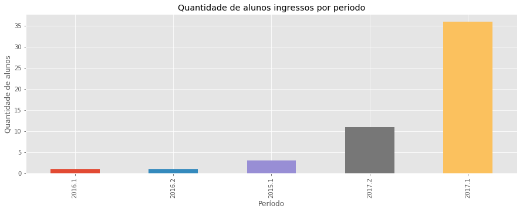

```python
ingressosPorAno = ingressos['ingresso'].value_counts().sort_values()
#Criando o gráfico de da quantidade de alunos que ingressaram na UFCG em cada periodo
ingressosPorAno.plot(kind='bar',figsize=(15,5))

#Enfeitando o gráfico
plt.title('Quantidade de alunos ingressos por periodo')
plt.xlabel('Período')
plt.ylabel('Quantidade de alunos')
plt.show()
```

As escolas visitantes que tiveram alunos aprovados no vestibular pode ser vistas abaixo

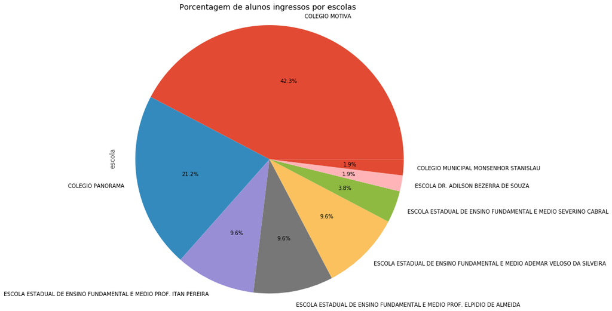

```python
aprovacoesEscolas = ingressos['escola'].value_counts()
#Criando o gráfico de da quantidade de alunos que ingressaram na UFCG em cada periodo
aprovacoesEscolas.plot(kind='pie',figsize=(10,10),autopct='%1.1f%%')

#Enfeitando o gráfico
plt.title('Porcentagem de alunos ingressos por escolas')
plt.axis('equal')
#plt.xlabel('Período')
#plt.ylabel('Quantidade de alunos')
plt.show()
```

```
Text(0.5,1,'Cursos que os alunos foram selecionados')
```

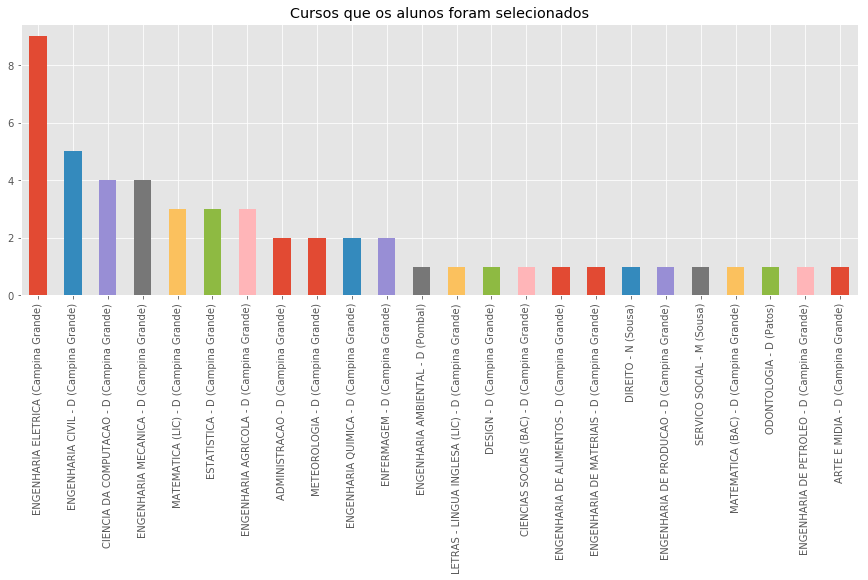

```python
#Criando gráfico dos cursos que os alunos ingressaram
cursos = ingressos['curso'].value_counts()
cursos.plot(kind='bar',figsize=(15,5))

plt.title('Cursos que os alunos foram selecionados')
```

```python
correlacaocurso = pd.read_csv('resultadosPesquisaCursos.csv')
```

O campus com mais selecionados foi Campus Central da UFCG, localizado em Campina Grande, evidenciando a importância da Praça das Profissões dentro do âmbito muncipal

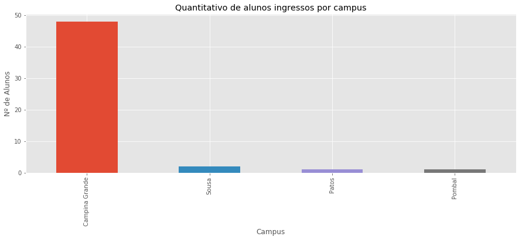

```python
#Quantitativo de alunos ingressos por campus
ingressosPorCampus = correlacaocurso['campus'].value_counts()
ingressosPorCampus.plot(kind='bar',figsize=(15,5))

plt.title('Quantitativo de alunos ingressos por campus')
plt.xlabel('Campus')
plt.ylabel('Nº de Alunos')
plt.show()
```

Podemos traçar um perfil dos cursos informados pelos alunos quando visitaram a Praça e o curso que ele passou no vestibular, analisando se as escolhas convergiram no mesmo curso, ou se o aluno optou por um curso da mesma áera ou ainda se o curso que ele queria no dia da visita não tem nenhuma correlação com o curso em que ele ingressou na instituição.

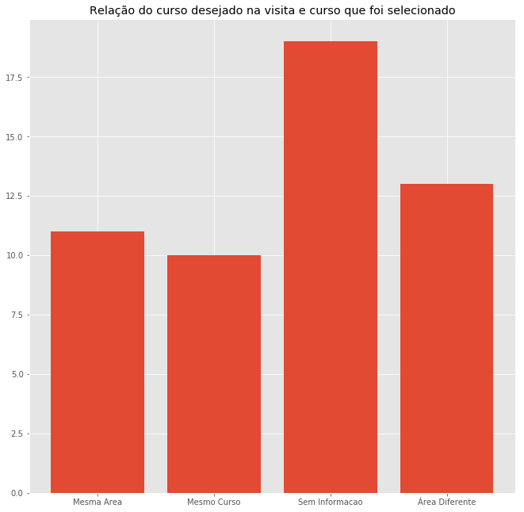

```python
#criando o gráfico da correlação dos cursos escolhidos pelo os que passou

x = ['Mesmo Curso','Mesma Area','Área Diferente','Sem Informacao'] #campos do eixo x
y = [10,11,13,19] # valores do campo y

plt.bar(x,y)
plt.rcParams['figure.figsize'] = (11,11 )
plt.title("Relação do curso desejado na visita e curso que foi selecionado")
plt.show()
```